# Netflix Analysis

Khoi Nguyen

2023-03-09

## Background

About this Dataset: Netflix is one of the most popular media and video streaming platforms. They have over 8000 movies or tv shows available on their platform, as of mid-2021, they have over 200M Subscribers globally. This tabular dataset consists of listings of all the movies and tv shows available on Netflix, along with details such as - cast, directors, ratings, release year, duration, etc.

```r
library(ggplot2)
library(readr)
library(dplyr)
library(lubridate)
netflix <- read_csv("netflix_titles.csv")
netflix$date_added <- mdy(netflix$date_added)
```

## Main Questions

Top 5 countries that have the most films added to Netflix in 2021 ?

What are the trends of releasing movie and TV shows in each continent ?

What are the trends of the contents released on Netflix over time in each continent ?

How is the distribution of the rating across continents ?

# Top 5 countries that have the most films added to Netflix in 2021

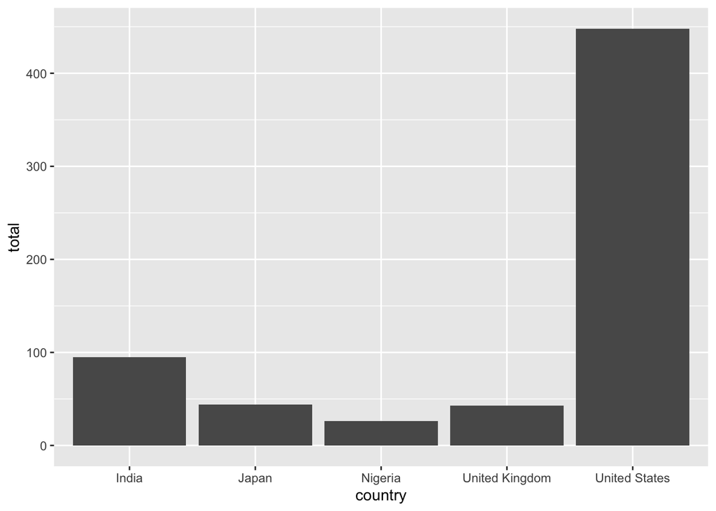

# Trends of movie and TV shows being released on Netflix in each continent over time

```r
# Now I want to do some analysis based on regions and continents so I will load another csv file
continents <- read_csv("continents2.csv")
# Since I only need the region and sub-region so I will only select those columns and the name column so I can later join the table
region_n_sub <- continents %>%
  select(region, `sub-region`, name)

# The column name for sub region is really bad for data analysis so I change it
region_n_sub$`sub-region` <- colnames("sub_region")

# Now let's remove NA values
region_n_sub_clean <- region_n_sub %>%
  filter(!is.na(region))

# Let's join the tables together !!!
netflix_join <- netflix %>%
  inner_join(region_n_sub_clean, by = c("country" = "name"))

netflix_join_region <- netflix_join %>%
  group_by(country, release_year, region) %>%
  summarize(total = n())
```

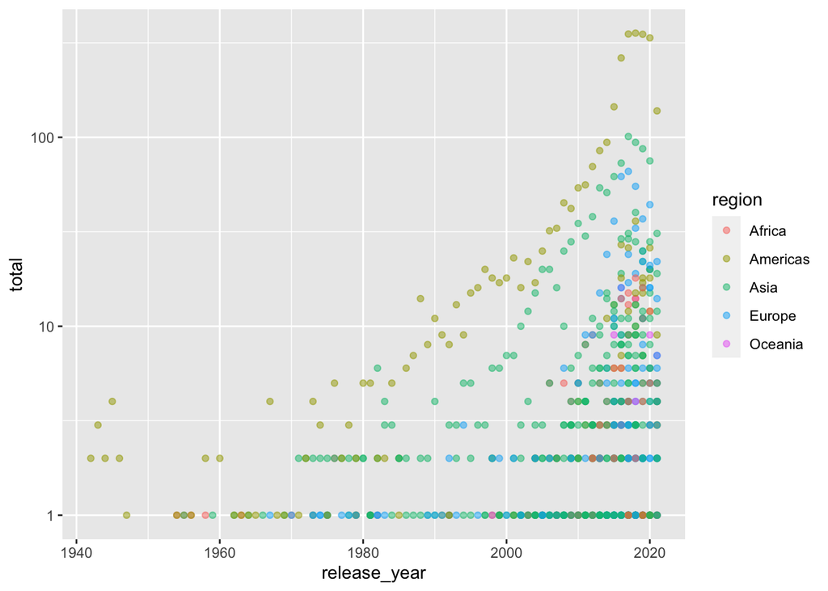

```r
# Let's create a scatterplot colored by region so they can see the trends of the released year between regions more clearly
ggplot(netflix_join_region, aes(release_year, total, color = region )) +
                geom_point(alpha = 0.5) +
                scale_y_log10()
```

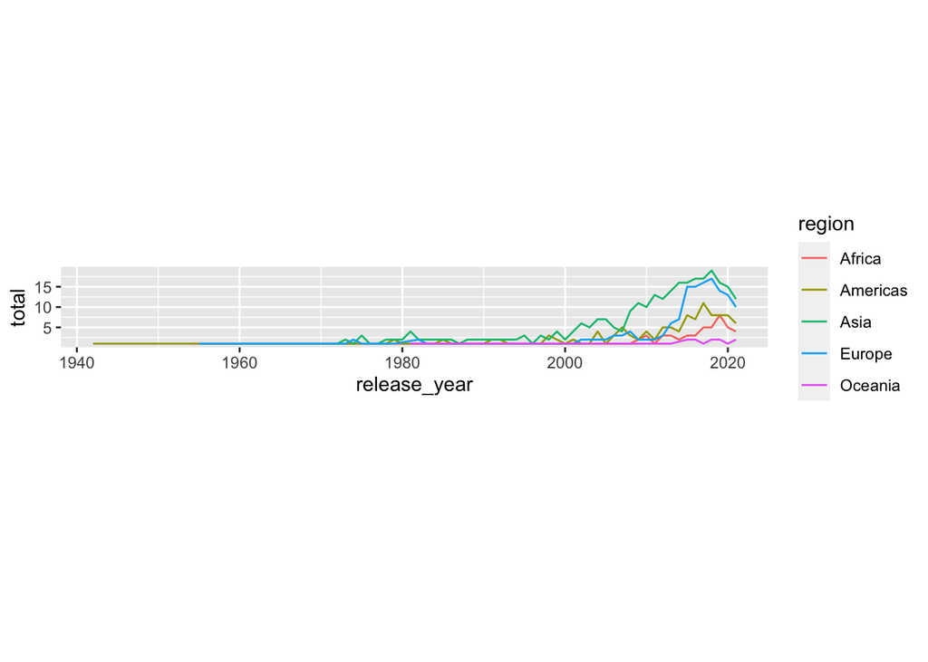

```r
# Let's create a line chart for these regions
# Firstly we need another table
netflix_cont <- netflix_join_region %>%
  group_by(region, release_year) %>%
  summarize(total = n())
ggplot(netflix_cont, aes(release_year, total, color = region)) +
                geom_line() +
                coord_fixed(1/2)
```

## Trends of the contents released on Netflix over time in each continent

There are only two types of content in this dataset which are “movie” and “TV Shows”

```r
# Now let's make some exploration to the Netflix type column to see the trend of Netflix types in each region
netflix_type_count <- netflix_join %>%
  group_by(region, type) %>%
  summarize(total = n())
```

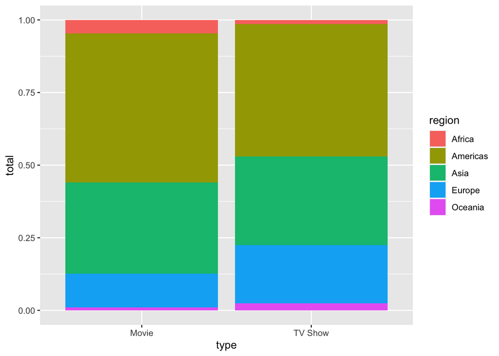

```r
ggplot(netflix_type_count, aes(type, total, fill = region)) +
  geom_col(position = "fill")
```

```r
# Let's see the Netflix type over time in each region
#First, we need a new table that also includes the year that is released
netflix_type_time <- netflix_join %>%
  mutate(year_added = year(date_added)) %>%
  group_by(region, type, year_added ) %>%
  summarize(total = n())
```

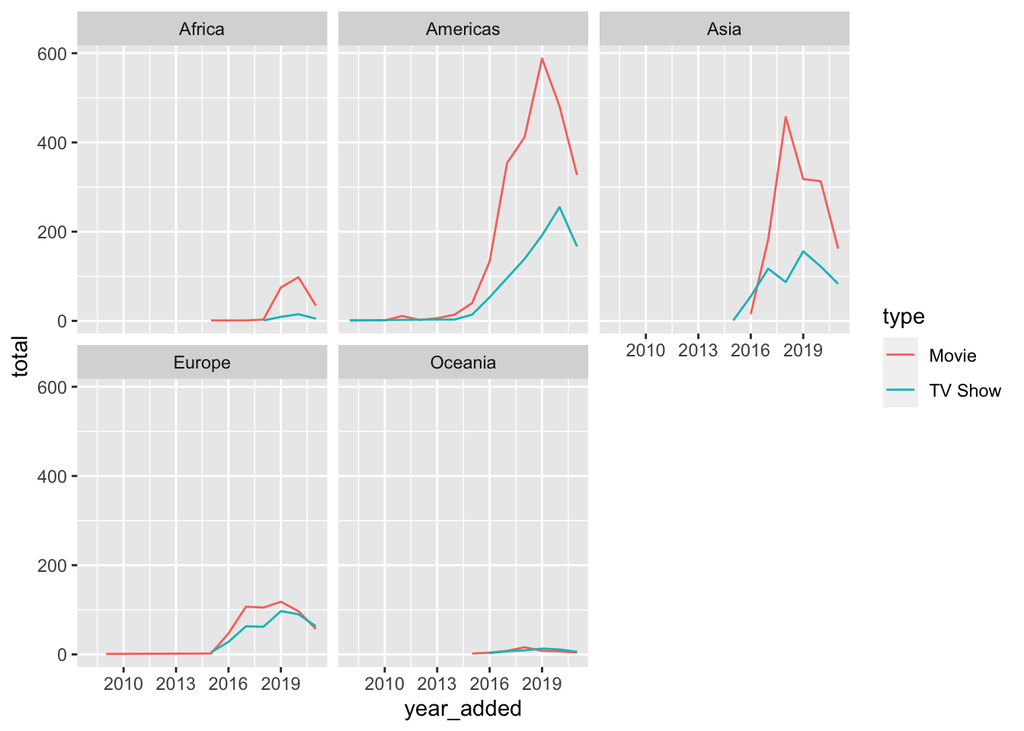

```r
ggplot(netflix_type_time, aes(year_added, total, color = type)) +
  geom_line() +
  facet_wrap(~ region)
```

## Rating distribution across continents

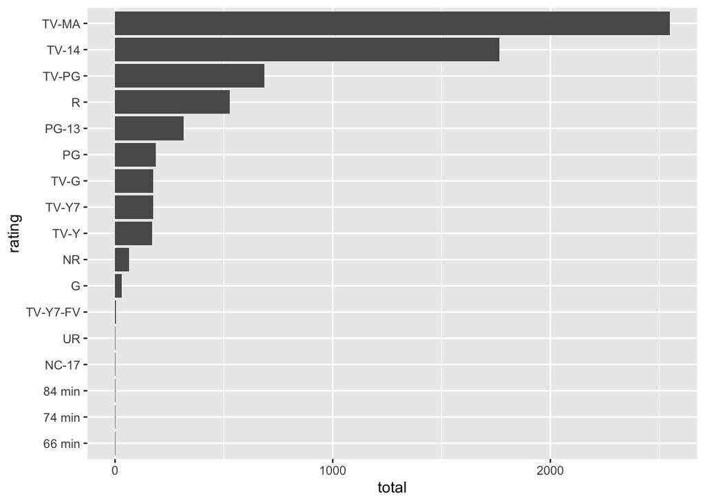

```r
# Let's make some anylysis upon movies rating, let's start with a simple count, remember to remove NA
netflix_rating <- netflix_join %>%
  group_by(rating) %>%
  summarise(total = n()) %>%
  filter(!is.na(rating))

# Making some changes to the order of the data so I can make a more informative bar charts
netflix_rating <- netflix_rating[order(-netflix_rating$total),]
netflix_rating$rating <- reorder(netflix_rating$rating, netflix_rating$total)

# Let's get a bar chart for comparison, since the chart is hard to read I will flip the axes
ggplot(netflix_rating, aes(rating, total)) +
  geom_col() +
  coord_flip()
```

```r
# Now let's see each rating's distributions across different regions
netflix_rating_by_region <- netflix_join %>%
  group_by(rating, region) %>%
  summarise(total = n()) %>%
  filter(!is.na(rating))
```

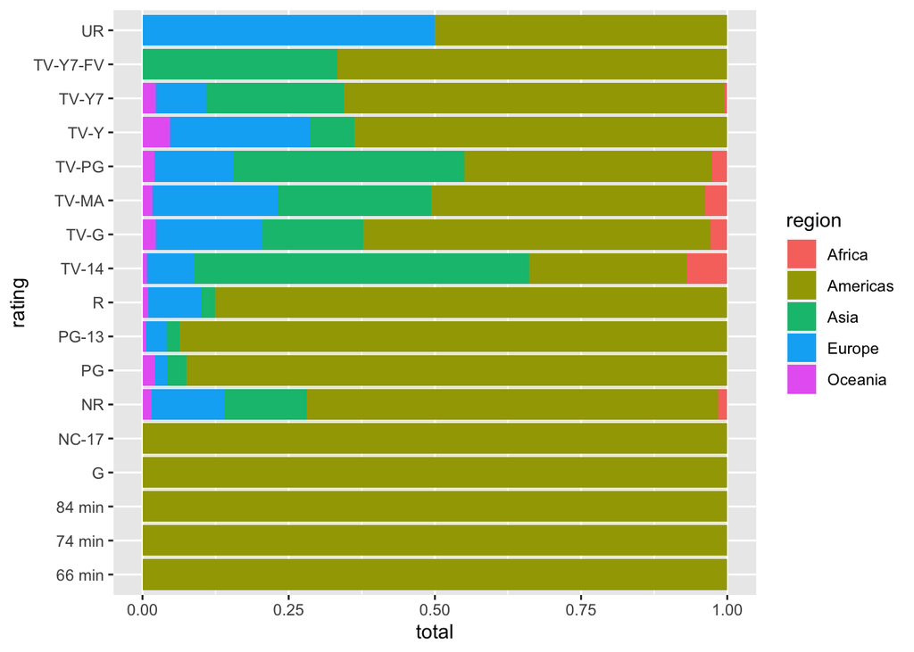

```r
 ggplot(netflix_rating_by_region, aes(rating, total, fill = region)) +
  geom_col(position = "fill") +
  coord_flip()
```

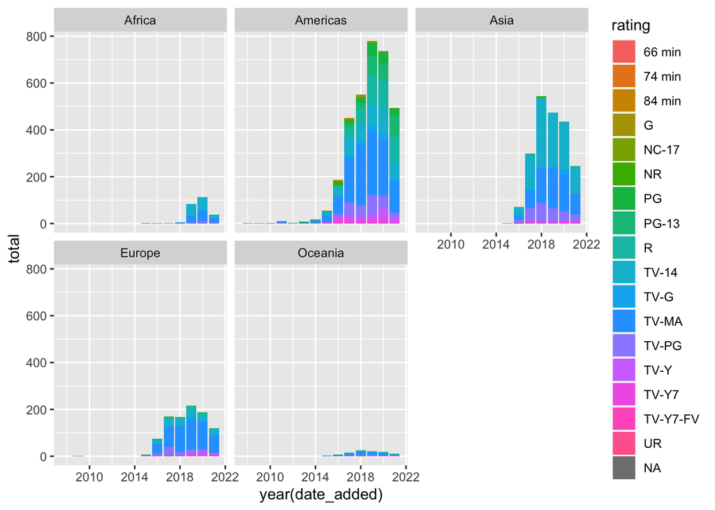

```r
# Let's create subplot for each region that visualize their rating trend over time
# Firstly we need another table
netflix_region_time <- netflix_join %>%
  group_by(region, year(date_added), rating) %>%
  summarize(total = n())
# Secondly, let's draw a bar chart
ggplot(netflix_region_time, aes(`year(date_added)`, total, fill = rating)) +
  geom_col() +
  facet_wrap(~ region)
```